# Lab 3

Audrey Omidsalar

9/10/2021

## 1. Read in the Data

```r
if (!file.exists("met_all.gz")){
download.file("https://raw.githubusercontent.com/USCbiostats/data-science-data/master/02_met/met_all.gz", "met_all.gz", method="libcurl", timeout = 60)}
met <- data.table::fread("met_all.gz")
```

## 2. Check the dimensions, headers, footers. How many columns, rows are there?

There are 2377343 rows and 30 columns

```r
dim(met)
```

```
## [1] 2377343      30
```

```r
head(met)
```

```
##    USAFID  WBAN year month day hour min  lat      lon elev wind.dir wind.dir.qc
## 1: 690150 93121 2019     8   1    0  56 34.3 -116.166  696      220           5
## 2: 690150 93121 2019     8   1    1  56 34.3 -116.166  696      230           5
## 3: 690150 93121 2019     8   1    2  56 34.3 -116.166  696      230           5
## 4: 690150 93121 2019     8   1    3  56 34.3 -116.166  696      210           5
## 5: 690150 93121 2019     8   1    4  56 34.3 -116.166  696      120           5
## 6: 690150 93121 2019     8   1    5  56 34.3 -116.166  696       NA           9
##    wind.type.code wind.sp wind.sp.qc ceiling.ht ceiling.ht.qc ceiling.ht.method
## 1:              N     5.7          5      22000             5                 9
## 2:              N     8.2          5      22000             5                 9
## 3:              N     6.7          5      22000             5                 9
## 4:              N     5.1          5      22000             5                 9
## 5:              N     2.1          5      22000             5                 9
## 6:              C     0.0          5      22000             5                 9
##    sky.cond vis.dist vis.dist.qc vis.var vis.var.qc temp temp.qc dew.point
## 1:        N    16093           5       N          5 37.2       5      10.6
## 2:        N    16093           5       N          5 35.6       5      10.6
## 3:        N    16093           5       N          5 34.4       5       7.2
## 4:        N    16093           5       N          5 33.3       5       5.0
## 5:        N    16093           5       N          5 32.8       5       5.0
## 6:        N    16093           5       N          5 31.1       5       5.6
##    dew.point.qc atm.press atm.press.qc       rh
## 1:            5    1009.9            5 19.88127
## 2:            5    1010.3            5 21.76098
## 3:            5    1010.6            5 18.48212
## 4:            5    1011.6            5 16.88862
## 5:            5    1012.7            5 17.38410
## 6:            5    1012.7            5 20.01540
```

```r
tail(met)
```

```
##    USAFID  WBAN year month day hour min    lat      lon elev wind.dir
## 1: 726813 94195 2019     8  31   18  56 43.650 -116.633  741       NA
## 2: 726813 94195 2019     8  31   19  56 43.650 -116.633  741       70
## 3: 726813 94195 2019     8  31   20  56 43.650 -116.633  741       NA
## 4: 726813 94195 2019     8  31   21  56 43.650 -116.633  741       10
## 5: 726813 94195 2019     8  31   22  56 43.642 -116.636  741       10
## 6: 726813 94195 2019     8  31   23  56 43.642 -116.636  741       40
##    wind.dir.qc wind.type.code wind.sp wind.sp.qc ceiling.ht ceiling.ht.qc
## 1:           9              C     0.0          5      22000             5
## 2:           5              N     2.1          5      22000             5
## 3:           9              C     0.0          5      22000             5
## 4:           5              N     2.6          5      22000             5
## 5:           1              N     2.1          1      22000             1
## 6:           1              N     2.1          1      22000             1
##    ceiling.ht.method sky.cond vis.dist vis.dist.qc vis.var vis.var.qc temp
## 1:                 9        N    16093           5       N          5 30.0
## 2:                 9        N    16093           5       N          5 32.2
## 3:                 9        N    16093           5       N          5 33.3
## 4:                 9        N    14484           5       N          5 35.0
## 5:                 9        N    16093           1       9          9 34.4
## 6:                 9        N    16093           1       9          9 34.4
##    temp.qc dew.point dew.point.qc atm.press atm.press.qc       rh
## 1:       5      11.7            5    1013.6            5 32.32509
## 2:       5      12.2            5    1012.8            5 29.40686
## 3:       5      12.2            5    1011.6            5 27.60422
## 4:       5       9.4            5    1010.8            5 20.76325
## 5:       1       9.4            1    1010.1            1 21.48631
## 6:       1       9.4            1    1009.6            1 21.48631
```

## 3. Take a look at the variables

```r
str(met)
```

```
## Classes 'data.table' and 'data.frame':   2377343 obs. of  30 variables:
##  $ USAFID           : int  690150 690150 690150 690150 690150 690150 690150 690150 690150 690150 ...
##  $ WBAN             : int  93121 93121 93121 93121 93121 93121 93121 93121 93121 93121 ...
##  $ year             : int  2019 2019 2019 2019 2019 2019 2019 2019 2019 2019 ...
##  $ month            : int  8 8 8 8 8 8 8 8 8 8 ...
##  $ day              : int  1 1 1 1 1 1 1 1 1 1 ...
##  $ hour             : int  0 1 2 3 4 5 6 7 8 9 ...
##  $ min              : int  56 56 56 56 56 56 56 56 56 56 ...
##  $ lat              : num  34.3 34.3 34.3 34.3 34.3 34.3 34.3 34.3 34.3 34.3 ...
##  $ lon              : num  -116 -116 -116 -116 -116 ...
##  $ elev             : int  696 696 696 696 696 696 696 696 696 696 ...
##  $ wind.dir         : int  220 230 230 210 120 NA 320 10 320 350 ...
##  $ wind.dir.qc      : chr  "5" "5" "5" "5" ...
##  $ wind.type.code   : chr  "N" "N" "N" "N" ...
##  $ wind.sp          : num  5.7 8.2 6.7 5.1 2.1 0 1.5 2.1 2.6 1.5 ...
```

[output cut: 17 more lines]

## 4. Take a closer look at the key variables

```r
table(met$year)
```

```
##
##    2019
## 2377343
```

```r
table(met$day)
```

```
##
##     1     2     3     4     5     6     7     8     9    10    11    12    13
## 75975 75923 76915 76594 76332 76734 77677 77766 75366 75450 76187 75052 76906
##    14    15    16    17    18    19    20    21    22    23    24    25    26
## 77852 76217 78015 78219 79191 76709 75527 75786 78312 77413 76965 76806 79114
##    27    28    29    30    31
## 79789 77059 71712 74931 74849
```

```r
table(met$hour)
```

```
##
##      0      1      2      3      4      5      6      7      8      9     10
##  99434  93482  93770  96703 110504 112128 106235 101985 100310 102915 101880
##     11     12     13     14     15     16     17     18     19     20     21
## 100470 103605  97004  96507  97635  94942  94184 100179  94604  94928  96070
##     22     23
##  94046  93823
```

```r
summary(met$temp)
```

```
##    Min. 1st Qu.  Median    Mean 3rd Qu.    Max.    NA's
##  -40.00   19.60   23.50   23.59   27.80   56.00   60089
```

```r
summary(met$elev)
```

```
##    Min. 1st Qu.  Median    Mean 3rd Qu.    Max.
##   -13.0   101.0   252.0   415.8   400.0  9999.0
```

```r
summary(met$wind.sp)
```

```
##    Min. 1st Qu.  Median    Mean 3rd Qu.    Max.    NA's
##    0.00    0.00    2.10    2.46    3.60   36.00   79693
```

After checking the data we should make the appropriate modifications. Replace elevations with 9999 as NA.

```r
met[met$elev==9999.0] <- NA
summary(met$elev)
```

```
##    Min. 1st Qu.  Median    Mean 3rd Qu.    Max.    NA's
##     -13     101     252     413     400    4113     710
```

The weather station with highest elevation is 4113 meters (after replacing elevations of 9999 with NA)

```r
met <- met[temp>-40]
met2 <- met[order(temp)]
head(met2)
```

```
##    USAFID WBAN year month day hour min    lat    lon elev wind.dir wind.dir.qc
## 1: 722817 3068 2019     8   1    0  56 38.767 -104.3 1838      190           5
## 2: 722817 3068 2019     8   1    1  56 38.767 -104.3 1838      180           5
## 3: 722817 3068 2019     8   3   11  56 38.767 -104.3 1838       NA           9
## 4: 722817 3068 2019     8   3   12  56 38.767 -104.3 1838       NA           9
## 5: 722817 3068 2019     8   6   21  56 38.767 -104.3 1838      280           5
## 6: 722817 3068 2019     8   6   22  56 38.767 -104.3 1838      240           5
##    wind.type.code wind.sp wind.sp.qc ceiling.ht ceiling.ht.qc ceiling.ht.method
## 1:              N     7.2          5         NA             9                 9
## 2:              N     7.7          5         NA             9                 9
## 3:              C     0.0          5         NA             9                 9
## 4:              C     0.0          5         NA             9                 9
## 5:              N     2.6          5         NA             9                 9
## 6:              N     7.7          5         NA             9                 9
##    sky.cond vis.dist vis.dist.qc vis.var vis.var.qc  temp temp.qc dew.point
## 1:        N       NA           9       N          5 -17.2       5        NA
## 2:        N       NA           9       N          5 -17.2       5        NA
## 3:        N       NA           9       N          5 -17.2       5        NA
## 4:        N       NA           9       N          5 -17.2       5        NA
## 5:        N       NA           9       N          5 -17.2       5        NA
## 6:        N       NA           9       N          5 -17.2       5        NA
##    dew.point.qc atm.press atm.press.qc rh
## 1:            9        NA            9 NA
## 2:            9        NA            9 NA
## 3:            9        NA            9 NA
## 4:            9        NA            9 NA
## 5:            9        NA            9 NA
## 6:            9        NA            9 NA
```

```r
tail(met2)
```

```
##    USAFID  WBAN year month day hour min    lat      lon elev wind.dir
## 1: 720267 23224 2019     8  31   19  35 38.955 -121.081  467      260
## 2: 690150 93121 2019     8  30   21  56 34.300 -116.166  696       NA
## 3: 690150 93121 2019     8  31   22  56 34.296 -116.162  625      320
## 4: 690150 93121 2019     8  31   21  56 34.300 -116.166  696       NA
## 5: 690150 93121 2019     8  29   22  56 34.300 -116.166  696      260
## 6: 720267 23224 2019     8  26   11  15 38.955 -121.081  467       NA
##    wind.dir.qc wind.type.code wind.sp wind.sp.qc ceiling.ht ceiling.ht.qc
## 1:           5              N     2.1          5      22000             5
## 2:           9              V     2.1          5      22000             5
## 3:           1              N     4.1          1      22000             1
## 4:           9              V     2.6          5      22000             5
## 5:           5              N     6.2          5      22000             5
## 6:           9              C     0.0          5      22000             5
##    ceiling.ht.method sky.cond vis.dist vis.dist.qc vis.var vis.var.qc temp
## 1:                 9        N    16093           5       N          5 52.0
## 2:                 9        N    16093           5       N          5 52.8
## 3:                 9        N    16093           1       9          9 52.8
## 4:                 9        N    16093           5       N          5 53.9
## 5:                 9        N    16093           5       N          5 54.4
## 6:                 9        N    16093           5       N          5 56.0
##    temp.qc dew.point dew.point.qc atm.press atm.press.qc        rh
## 1:       6      27.0            5        NA            9 25.400655
## 2:       6      -2.2            5    1009.2            5  3.396832
## 3:       2     -11.1            2    1007.9            1  1.666744
## 4:       6     -11.7            5    1008.6            5  1.494442
## 5:       6       3.3            5    1009.5            5  4.709481
## 6:       5        NA            9        NA            9        NA
```

## 5. Check the data against an external data source

Removed temperatures less than -15C, and made a new dataset (met2) which is ordered according to temperature. The new minimum temperature is -3C

```r
met <- met[temp>-15]
met2 <- met[order(temp)]
head(met2)
```

```
##    USAFID  WBAN year month day hour min    lat      lon elev wind.dir
## 1: 726764 94163 2019     8  27   11  50 44.683 -111.116 2025       NA
## 2: 726764 94163 2019     8  27   12  10 44.683 -111.116 2025       NA
## 3: 726764 94163 2019     8  27   12  30 44.683 -111.116 2025       NA
## 4: 726764 94163 2019     8  27   12  50 44.683 -111.116 2025       NA
## 5: 720411   137 2019     8  18   12  35 36.422 -105.290 2554       NA
## 6: 726764 94163 2019     8  26   12  30 44.683 -111.116 2025       NA
##    wind.dir.qc wind.type.code wind.sp wind.sp.qc ceiling.ht ceiling.ht.qc
## 1:           9              C       0          5      22000             5
## 2:           9              C       0          5      22000             5
## 3:           9              C       0          5      22000             5
## 4:           9              C       0          5      22000             5
## 5:           9              C       0          5      22000             5
## 6:           9              C       0          5      22000             5
##    ceiling.ht.method sky.cond vis.dist vis.dist.qc vis.var vis.var.qc temp
## 1:                 9        N    16093           5       N          5 -3.0
## 2:                 9        N    16093           5       N          5 -3.0
## 3:                 9        N    16093           5       N          5 -3.0
## 4:                 9        N    16093           5       N          5 -3.0
## 5:                 9        N    16093           5       N          5 -2.4
## 6:                 9        N    16093           5       N          5 -2.0
##    temp.qc dew.point dew.point.qc atm.press atm.press.qc       rh
## 1:       C      -5.0            C        NA            9 86.26537
## 2:       5      -4.0            5        NA            9 92.91083
## 3:       5      -4.0            5        NA            9 92.91083
## 4:       C      -4.0            C        NA            9 92.91083
## 5:       5      -3.7            5        NA            9 90.91475
## 6:       5      -3.0            5        NA            9 92.96690
```

## 6. Calculate summary statistics

Select the weather station with maximum elevation

```r
elev <- met[elev==max(elev)]
summary(elev)
```

```
##      USAFID            WBAN          year          month        day
##  Min.   :720385   Min.   :419   Min.   :2019   Min.   :8   Min.   : 1.0
##  1st Qu.:720385   1st Qu.:419   1st Qu.:2019   1st Qu.:8   1st Qu.: 8.0
##  Median :720385   Median :419   Median :2019   Median :8   Median :16.0
##  Mean   :720385   Mean   :419   Mean   :2019   Mean   :8   Mean   :16.1
##  3rd Qu.:720385   3rd Qu.:419   3rd Qu.:2019   3rd Qu.:8   3rd Qu.:24.0
##  Max.   :720385   Max.   :419   Max.   :2019   Max.   :8   Max.   :31.0
##
##       hour            min             lat            lon              elev
##  Min.   : 0.00   Min.   : 6.00   Min.   :39.8   Min.   :-105.8   Min.   :4113
##  1st Qu.: 6.00   1st Qu.:13.00   1st Qu.:39.8   1st Qu.:-105.8   1st Qu.:4113
##  Median :12.00   Median :36.00   Median :39.8   Median :-105.8   Median :4113
##  Mean   :11.66   Mean   :34.38   Mean   :39.8   Mean   :-105.8   Mean   :4113
##  3rd Qu.:18.00   3rd Qu.:53.00   3rd Qu.:39.8   3rd Qu.:-105.8   3rd Qu.:4113
##  Max.   :23.00   Max.   :59.00   Max.   :39.8   Max.   :-105.8   Max.   :4113
##
##     wind.dir     wind.dir.qc        wind.type.code        wind.sp
##  Min.   : 10.0   Length:2117        Length:2117        Min.   : 0.000
##  1st Qu.:250.0   Class :character   Class :character   1st Qu.: 4.100
##  Median :300.0   Mode  :character   Mode  :character   Median : 6.700
##  Mean   :261.5                                         Mean   : 7.245
##  3rd Qu.:310.0                                         3rd Qu.: 9.800
##  Max.   :360.0                                         Max.   :21.100
##  NA's   :237                                           NA's   :168
##   wind.sp.qc          ceiling.ht    ceiling.ht.qc   ceiling.ht.method
##  Length:2117        Min.   :   30   Min.   :5.000   Length:2117
##  Class :character   1st Qu.: 2591   1st Qu.:5.000   Class :character
##  Mode  :character   Median :22000   Median :5.000   Mode  :character
##                     Mean   :15145   Mean   :5.008
##                     3rd Qu.:22000   3rd Qu.:5.000
##                     Max.   :22000   Max.   :9.000
##                     NA's   :4
##    sky.cond            vis.dist     vis.dist.qc          vis.var
##  Length:2117        Min.   :    0   Length:2117        Length:2117
##  Class :character   1st Qu.:16093   Class :character   Class :character
##  Mode  :character   Median :16093   Mode  :character   Mode  :character
##                     Mean   :15913
##                     3rd Qu.:16093
##                     Max.   :16093
##                     NA's   :683
##   vis.var.qc             temp         temp.qc            dew.point
##  Length:2117        Min.   : 1.00   Length:2117        Min.   :-6.0000
##  Class :character   1st Qu.: 6.00   Class :character   1st Qu.: 0.0000
##  Mode  :character   Median : 8.00   Mode  :character   Median : 0.0000
##                     Mean   : 8.13                      Mean   : 0.8729
##                     3rd Qu.:10.00                      3rd Qu.: 2.0000
##                     Max.   :15.00                      Max.   : 7.0000
##
##  dew.point.qc         atm.press     atm.press.qc       rh
##  Length:2117        Min.   : NA    Min.   :9     Min.   :53.63
##  Class :character   1st Qu.: NA    1st Qu.:9     1st Qu.:58.10
##  Mode  :character   Median : NA    Median :9     Median :61.39
##                     Mean   :NaN    Mean   :9     Mean   :60.62
##                     3rd Qu.: NA    3rd Qu.:9     3rd Qu.:61.85
##                     Max.   : NA    Max.   :9     Max.   :70.01
##                     NA's   :2117
```

Correlation between temperature and wind speed

```r
cor(elev$temp, elev$wind.sp, use="complete")
```

```
## [1] -0.09373843
```

Correlation between temperature and hour

```r
cor(elev$temp, elev$hour, use="complete")
```

```
## [1] 0.4397261
```

Correlation between wind speed and day

```r
cor(elev$wind.sp, elev$day, use="complete")
```

```
## [1] 0.3643079
```

Correlation between wind speed and hour

```r
cor(elev$wind.sp, elev$hour, use="complete")
```

```
## [1] 0.08807315
```

Correlation between temperature and day

```r
cor(elev$temp, elev$day, use="complete")
```

```
## [1] -0.003857766
```

## 7. Exploratory graphs

Looking at distribution of elevations

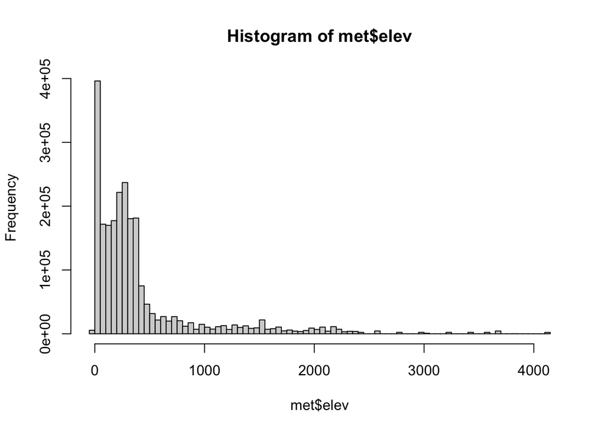

```r
hist(met$elev, breaks=100)
```

Distribution of temperature

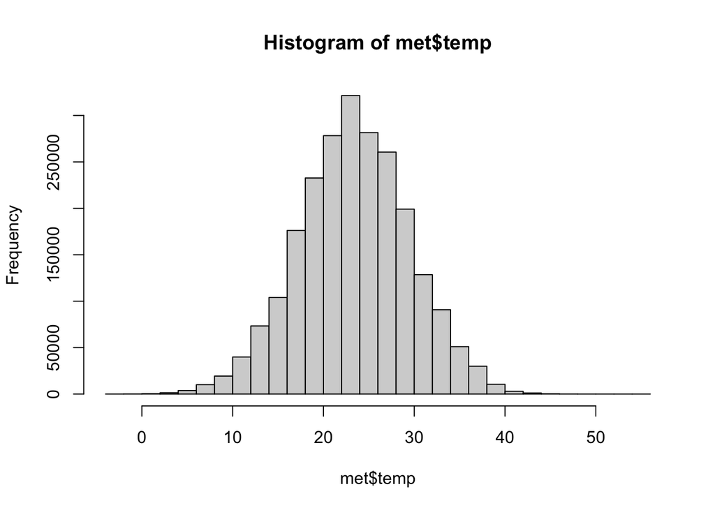

```r
hist(met$temp)
```

Distribution of wind speed

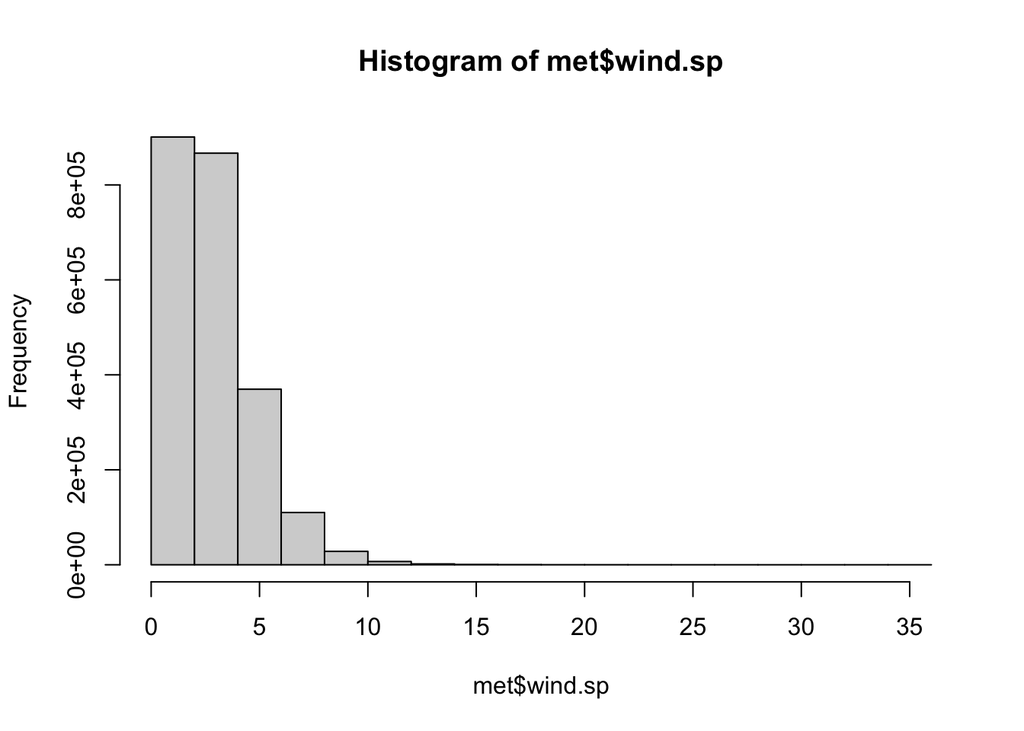

```r
hist(met$wind.sp)
```

Mapping where the weather station with highest elevation is located.

```r
leaflet(elev) %>%
  addProviderTiles('OpenStreetMap') %>%
  addCircles(lat=~lat,lng=~lon, opacity=1, fillOpacity=1, radius=100)
```

[interactive chart not shown]

```r
library(lubridate)
elev$date <- with(elev, ymd_h(paste(year, month, day, hour, sep= ' ')))
summary(elev$date)
```

```
##                  Min.               1st Qu.                Median
## "2019-08-01 00:00:00" "2019-08-08 11:00:00" "2019-08-16 22:00:00"
##                  Mean               3rd Qu.                  Max.
## "2019-08-16 14:09:56" "2019-08-24 11:00:00" "2019-08-31 22:00:00"
```

```r
elev <- elev[order(date)]
head(elev)
```

```
##    USAFID WBAN year month day hour min  lat      lon elev wind.dir wind.dir.qc
## 1: 720385  419 2019     8   1    0  36 39.8 -105.766 4113      170           5
## 2: 720385  419 2019     8   1    0  54 39.8 -105.766 4113      100           5
## 3: 720385  419 2019     8   1    1  12 39.8 -105.766 4113       90           5
## 4: 720385  419 2019     8   1    1  35 39.8 -105.766 4113      110           5
## 5: 720385  419 2019     8   1    1  53 39.8 -105.766 4113      120           5
## 6: 720385  419 2019     8   1    2  12 39.8 -105.766 4113      120           5
##    wind.type.code wind.sp wind.sp.qc ceiling.ht ceiling.ht.qc ceiling.ht.method
## 1:              N     8.8          5       1372             5                 M
## 2:              N     2.6          5       1372             5                 M
## 3:              N     3.1          5       1981             5                 M
## 4:              N     4.1          5       2134             5                 M
## 5:              N     4.6          5       2134             5                 M
## 6:              N     6.2          5      22000             5                 9
##    sky.cond vis.dist vis.dist.qc vis.var vis.var.qc temp temp.qc dew.point
## 1:        N       NA           9       N          5    9       5         1
## 2:        N       NA           9       N          5    9       5         1
## 3:        N       NA           9       N          5    9       5         2
## 4:        N       NA           9       N          5    9       5         2
## 5:        N       NA           9       N          5    9       5         2
## 6:        N       NA           9       N          5    9       5         2
##    dew.point.qc atm.press atm.press.qc       rh                date
## 1:            5        NA            9 57.61039 2019-08-01 00:00:00
## 2:            5        NA            9 57.61039 2019-08-01 00:00:00
## 3:            5        NA            9 61.85243 2019-08-01 01:00:00
## 4:            5        NA            9 61.85243 2019-08-01 01:00:00
## 5:            5        NA            9 61.85243 2019-08-01 01:00:00
## 6:            5        NA            9 61.85243 2019-08-01 02:00:00
```

Time series plot - date versus temperature. The temperature fluctuates throughout the day, but the maximum and minimum temperatures are staying roughly the same throughout the month.

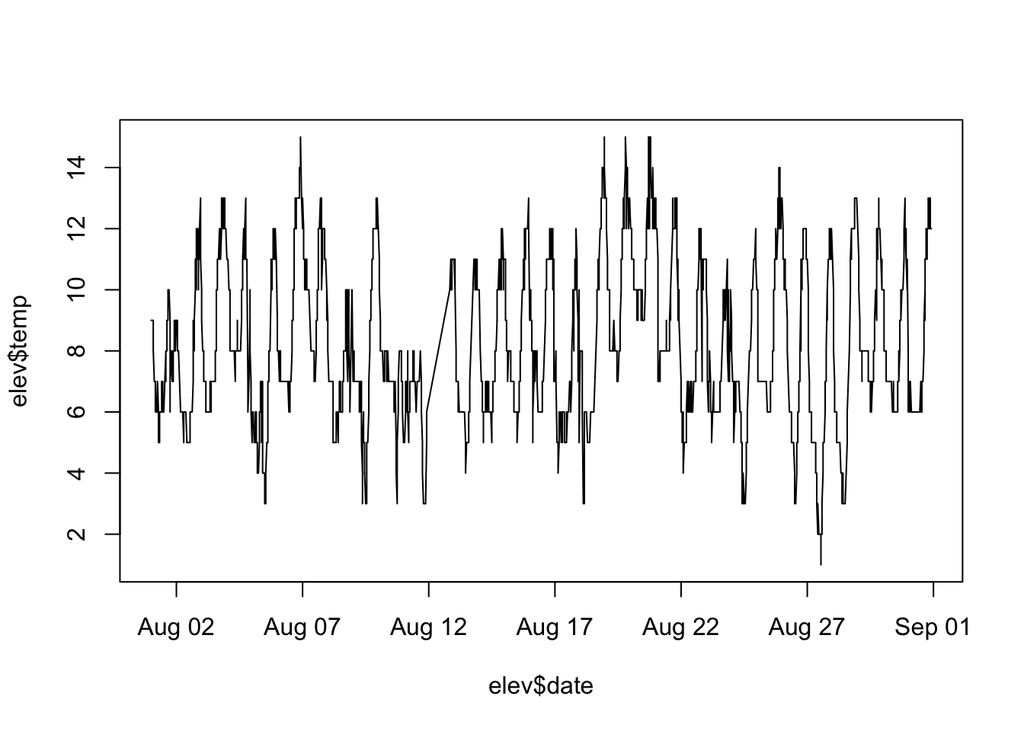

```r
plot(elev$date, elev$temp, type='l')
```

Time series plot - date versus wind speed. Wind speed fluctuates throughout the day, and peaks twice throughout the month (once around August 17th and again around August 25th).

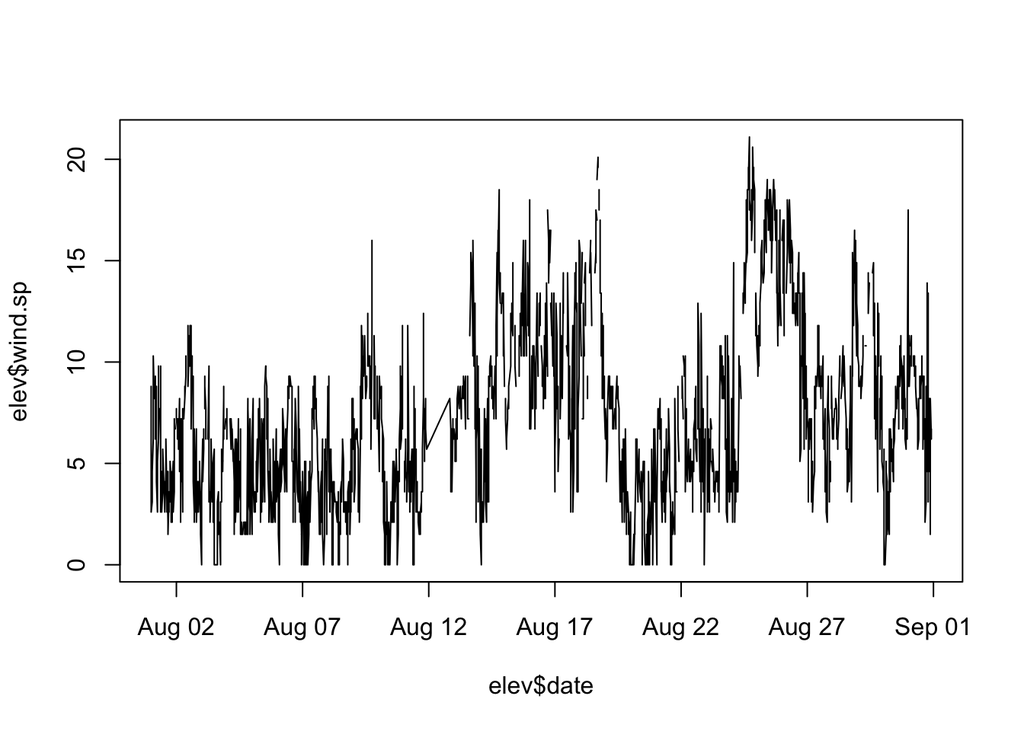

```r
plot(elev$date, elev$wind.sp, type='l')
```